# Simulate RICLPM with selection bias and use it for a sensitivity analysis

Kristoffer

2021-08-20

```r
knitr::opts_knit$set(root.dir = "~/gametime-longitudinal")
library(tidyverse)
library(lavaan)
```

Let’s investigate the effect of selection bias. Here I’m going to assume that there is a negative lagged effect of gaming on well-being, and see how much selection bias that would be needed to make this effect zero in the self-selected sample.

Here I’ve changed the simulation function allow the cross-lagged effects to differ per individual (random effects).

```r
source("Models/RI-CLPM/simulate-RICLPM-data.R")

params <- list(
    n = 10000,
    # beta = autoregressive params
    beta_2x = 0.66,
    beta_2y = 0.55,
    beta_3x = 0.40,
    beta_3y = 0.33,
    # gamma = cross-lagged effects
    gamma_2y = -1, # game_t1 -> well-being_t2
    gamma_2x = 0, # well-being_t1 -> game_t2
    gamma_3y = -1, # game_t2 -> well-being_t3
    gamma_3x = 0, # well-being_t2 -> game_t3
    # Random effects
    gamma_2y_sd = 0.5, # game_t1 -> well-being_t2
    gamma_2x_sd = 0.5, # well-being_t1 -> game_t2
    gamma_3y_sd = 0.5, # game_t2 -> well-being_t3
    gamma_3x_sd = 0.5, # well-being_t2 -> game_t3
    x_mean = 2,
    y_mean = 4,
    ## covariances
    sd_wx1 = 1,
    sd_wy1 = 1,
    cor_wx1_wy1 = 0.5,
    sd_wx2 = 1.33,
    sd_wy2 = 1.33,
    cor_wx2_wy2 = 0.6,
    sd_wx3 = 1.33,
    sd_wy3 = 1.33,
    cor_wx3_wy3 = 0.44,
    sd_x_RE = 1.2,
    sd_y_RE = 1.2,
    cor_xy_intercepts = 0.33,
    keep_cross_effects = TRUE
    )

set.seed(1338)
d <- do.call(sim_RICLPM_data, params)
```

```r
colMeans(d)
```

```
##           x1           x2           x3           y1           y2           y3          U_x          U_y     gamma_2x     gamma_2y     gamma_3x     gamma_3y
##  1.989349202  1.985905341  1.988730769  3.986128582  3.974944930  3.989629599 -0.013715446 -0.033538860 -0.008401895 -0.991204469  0.002346391 -0.991204469
```

```r
apply(d, 2, sd)
```

```
##        x1        x2        x3        y1        y2        y3       U_x       U_y  gamma_2x  gamma_2y  gamma_3x  gamma_3y
## 1.5663477 1.9729731 2.0677224 1.5507654 2.0457321 2.4962485 1.1968963 1.2000153 0.5048442 0.4999683 0.4967082 0.4999683
```

# lavaan RICLPM

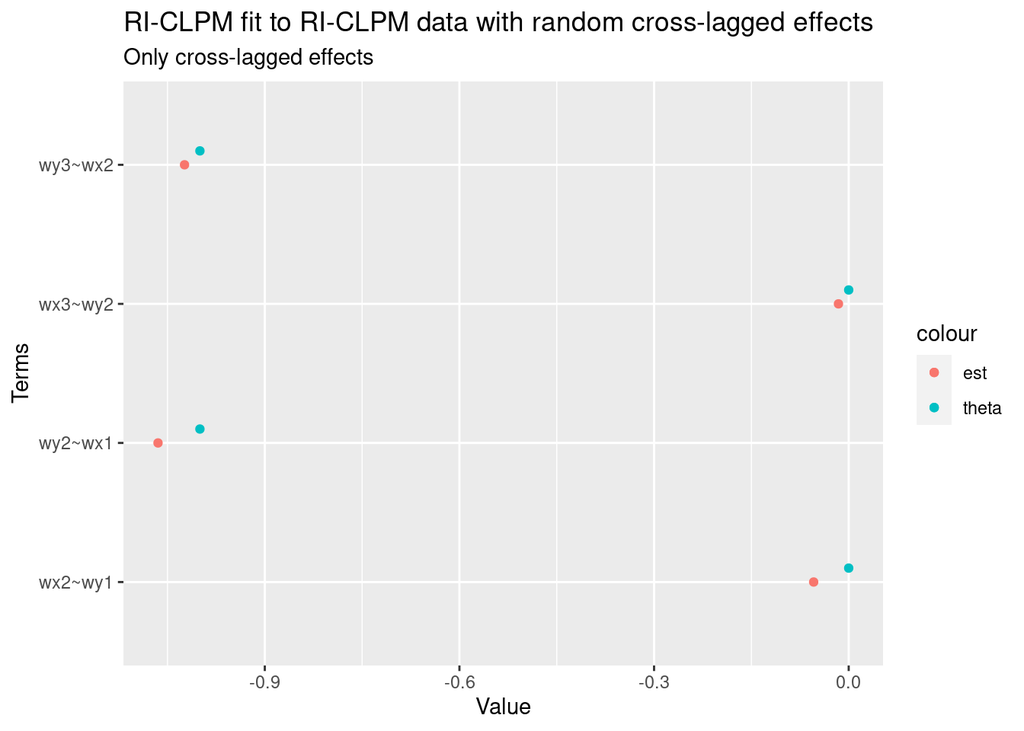

Estimates are correct.

## Add selection Bias

In the whole population I assume that there is on average a negative effect of time spent gaming on well-being (because wrongly concluding there is a null effect when it is actually negative is the biggest concern). For simplicity, I’m just selecting directly on the $\text{game time}_{t - i} \rightarrow \text{well-being}_t$ effect here. So that individuals where the effect is weaker or positive are more likely to join the study. In a sample of experienced and older gamers, it’s conceivable that their decision to join the study is related to how they’ve managed to fit games into their lives. This is not that unlikely, but the mechanism is likely more indirect.

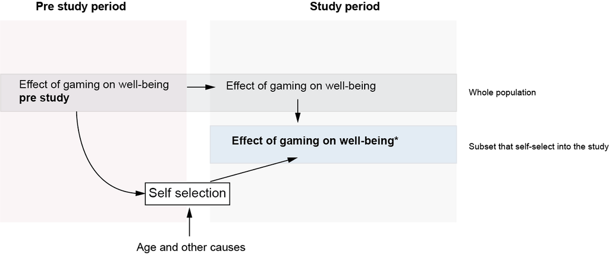

I’ve set the response rate to 3%, and use a logistic function to convert $\text{game time}_{t - i} \rightarrow \text{well-being}_t$ into individual probabilities of joining the study.

```r
# marginal response rate
resp_rate <- 0.03

# OR for likelihood of joining the study for every 1 increase
# in cross-lagged game -> well-being effect
log_OR <- log(100)

# this is bascially a GLMM, so approximate the marginal intercept
# to make the marginal response rate be the same for different OR values
C <- (16 * sqrt(3)) / (15 * pi)
intercept <- qlogis(resp_rate) * sqrt(C^2 * var(d$gamma_2y * log_OR) + 1)
d$p <- plogis(intercept + (d$gamma_2y - mean(d$gamma_2y)) * log_OR)
d$included <- rbinom(nrow(d), 1, d$p)
```

The red curve in the figure below represent the self-selection process, and the dark blue straight line represent no selection.

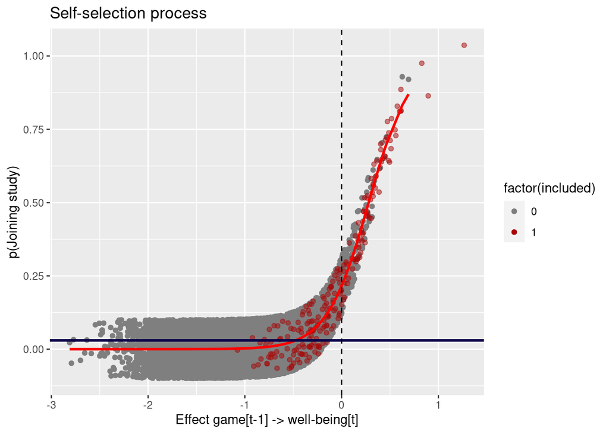

```r
ggplot(filter(d, included == 0),
        aes(gamma_2y, p, color = factor(included))
    ) +
    geom_point(
        position = position_jitter(width = 0, height = 0.1),
        alpha = 1
        ) +
    geom_point(
        data = filter(d, included == 1),
        position = position_jitter(width = 0, height = 0.1),
        alpha = 0.5
        ) +
    geom_line(color = "red", size = 1) +
    geom_hline(yintercept = resp_rate, color = "#0a0349", size = 1) +
    geom_vline(xintercept = 0, linetype = "dashed") +
        scale_color_manual(values = c("gray50", "#a70808")) +
        labs(
            title = "Self-selection process",
            x = "Effect game[t-1] -> well-being[t]",
            y = "p(Joining study)"
        )
```

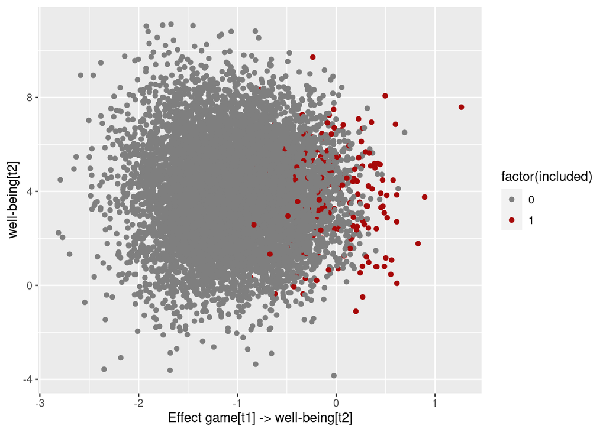

```r
ggplot(d, aes(gamma_2y, y2, color=factor(included))) +
    geom_point() +
    scale_color_manual(values = c("gray50", "#a70808")) +
    labs(x = "Effect game[t1] -> well-being[t2]", y = "well-being[t2]")
```

```r
d_selection <- filter(d, included == 1)

## response rate
nrow(d_selection) / nrow(d)
```

```
## [1] 0.0213
```

```r
## refit to subset of responders
fit_RICLPM <- lavaan(
    riclpm,
    data = d_selection,
    meanstructure = TRUE,
    int.ov.free = TRUE
)
```

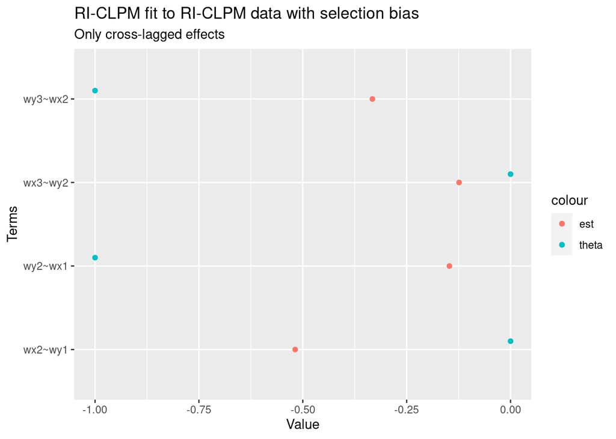

[output not shown]